# Coursework Report

*N* removed NAs: 2

*N* removed typo: 1

*N* removed <18: 16

*N* total clean: 131

| Group | *N* | *M*<sub>age</sub> | *M*<sub>rating</sub> |
| --- | --- | --- | --- |
| Control | 68 | 21.07 | 5.99 |
| Experim | 63 | 21.11 | 6.70 |

**Main analysis results**

*t*(129) = -5.08, *p* < .001

[interactive chart not shown]

[figure not shown]

[interactive chart not shown]

# Coursework Report

Analysing Data, Spring 2020

# Methods

## Design

The aim of this study is to examine whether the colour red affects attractiveness of and individual in the eyes of the opposite sex. The experiment uses three 9-point numerical rating scales tied to three statements; ‘How attractive is this person?’, ‘This person is pleasant to look at?’, and ‘If i met this person in public, i would find them attractive’. A high-score indicates that the participant strongly agrees with the statement, and a low score indicates that they strongly disagrees. The participants, who will all be young adults between the ages of 18 and 25, will be split relatively equally between control and experimental groups. Therefore, The hypothesis of this experiment states that viewing red promotes a higher level of attractedness and sexual desire towards men for women. IN order to test the significance of the results, the results will be processed through a two sample t-test with a 0.01 significance level, to ensure that the uncertainty to which the results could be due to chance is minimised.

# Results

From a visual analysis, the results appear to indicate a higher level of ratings in the experimental condition than in the control condition (see graph).

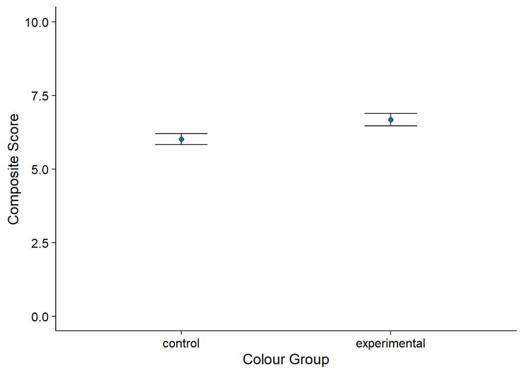

The standard deviation indicates a small degree of variance around the mean, signifing that the data gathered is precise (see table 1). The table also shows that the participants were relatively evenly distributed across both conditions. This means that any errors due to sample size will not affect the precision of the experiment.

Table 1: Descriptive statistics by Condition

| condition | *N* | % | *M*<sub>age</sub> | *SD*<sub>age</sub> | *M*<sub>rating</sub> | *SD*<sub>rating</sub> |
| --- | --- | --- | --- | --- | --- | --- |
| control | 66 | 52.38 | 20.88 | 1.94 | 6.02 | 0.78 |
| experimental | 60 | 47.62 | 20.78 | 2.03 | 6.68 | 0.82 |

# Discussion

The experiment found a positive increase in attractiveness ratings for men from women of approximately 11% in the experimental condition compared with the control condition. This was found to be statistically significant, and proved the alternate hypothesis that the presence of red does increase the attractiveness of an individual towards the opposite sex compared to the presence of white. Since this is a replication of previous research (Elliot et al., 2010), there are no groundbreaking discoveries that arise from this experiment. THe results gained are consistent with those found in experiment one of the original study, which strenghtens its findings, as well as its validity. While red is one of the most-researched colours when referring to attractiveness, findings tend to vary. For example, Peperkoorn (Pepperkoorn, Roberts & Pollet., 2015) presented multiple experiments that found no evidence of the red effect, even when replicating a previous experiment with a larger sample size that had found evidence of the red effect. This may be the result of not controlling for attractiveness beforehand, as research by Young (Young., 2015) found evidence to support the red effect, this only occured with faces that had been pre-rated as attractive, and this did not occur with faces that were considered unattractive. This could therefore argue that red, and with some further research colour in general, can only affect feelings of attraction that already exist. Further research could also analyse the effect unattractive colours (e.g. orange and brown) have on attractive and unattractive faces, to examine whether the reverse is true.

The main limitation of this study surrounds the decision to only use female participants with a male image. This affects the generalizability of the study, as these findings cannot be used in a male focused situation. This is also true for the age range, as the study only uses young adult participants.The study did attempt to remove any chance of demand characteristics and removing anyone who guessed close to the true aim of the experiment. The usage of imaging software to change the colour of the shirt is commendable, as it means that any changes across conditions can be purely isolated towards the change in shirt colour.

In conclusion, this experiment finds that the colour red does increase attractiveness ratings of men from women in terms of clothing colour, in comparison to white. Further research to be conducted should examine how this relationship functions amongst a wider spectrum of colours, as well as repeating the study with male participants, or lgbt individuals to examine if the relationship still stands.

# References

Elliot, A., Niesta Kayser, D., Greitemeyer, T., Lichtenfeld, S., Gramzow, R., Maier, M., & Liu, H. (2010). Red, rank, and romance in women viewing men. Journal Of Experimental Psychology: General, 139(3), 399-417. doi: 10.1037/a0019689

Pazda, A., Elliot, A., & Greitemeyer, T. (2013). Perceived sexual receptivity and fashionableness: Separate paths linking red and black to perceived attractiveness. Color Research & Application, 39(2), 208-212. doi: 10.1002/col.21804

Peperkoorn, L., Roberts, S., & Pollet, T. (2016). Revisiting the Red Effect on Attractiveness and Sexual Receptivity. Evolutionary Psychology, 14(4), 147470491667384. doi: 10.1177/1474704916673841

Young, S. (2015). The effect of red on male perceptions of female attractiveness: Moderation by baseline attractiveness of female faces. European Journal Of Social Psychology, 45(2), 146-151. doi: 10.1002/ejsp.2098